# Project 1

Yandong Xiong

1/19/2021

# Introduction

This project is to look deeper into the patterns and characteristics of voter behaviors to the 2016 Election. The dataset, downloaded from ANES website, was designed and collected by the ANES Principal Investigators and staff with design input from the ANES advisory board and contributors to the ANES Online Commons.

The initial part is “Data Exploring”, which includes import, manipulations and basic view on the raw dataset. Then, “Inspection” for each variable in the studied dataset. In addition, “Visualization” on properties and patterns of the voters. The fianl part is discussing people’s registration-turnout status based on two properties.

# Data exploring

```r
# change the working directory to the data file location
setwd("~/Documents/GitHub/Spring2021-Project1-yx2659/data")

# read the dataset
dt <- read_sav("anes_timeseries_2016.sav")

# basic lookup for the raw dataset
head(dt)
```

```
## # A tibble: 6 x 1,842
##   version V160001 V160001_orig V160101 V160101f V160101w V160102 V160102f
##   <chr>     <dbl>        <dbl>   <dbl>    <dbl>    <dbl>   <dbl>    <dbl>
## 1 ANES20…       1       300001   0.827    0.888        0   0.842    0.927
## 2 ANES20…       2       300002   1.08     1.16         0   1.01     1.08
## 3 ANES20…       3       300003   0.388    0.416        0   0.367    0.398
## 4 ANES20…       4       300004   0.360    0.385        0   0.366    0.418
## 5 ANES20…       5       300006   0.647    0.693        0   0.646    0.726
## 6 ANES20…       6       300007   0.706    0.759        0   0.688    0.725
## # … with 1,834 more variables: V160102w <dbl>, V160201 <dbl>, V160201f <dbl>,
## #   V160201w <dbl>, V160202 <dbl>, V160202f <dbl>, V160202w <dbl>,
## #   V160501 <dbl+lbl>, V160502 <dbl+lbl>, V161001 <dbl+lbl>, V161002 <dbl+lbl>,
## #   V161003 <dbl+lbl>, V161004 <dbl+lbl>, V161005 <dbl+lbl>, V161006 <dbl+lbl>,
## #   V161007 <dbl+lbl>, V161008 <dbl+lbl>, V161009 <dbl+lbl>,
## #   V161010a <dbl+lbl>, V161010b <dbl+lbl>, V161010c <dbl+lbl>,
## #   V161010d <dbl+lbl>, V161010e <chr>, V161010f <dbl>, V161011 <dbl+lbl>,
## #   V161011a <dbl+lbl>, V161012 <dbl+lbl>, V161013a <dbl+lbl>,
## #   V161013b <dbl+lbl>, V161014 <dbl+lbl>, V161015a <dbl+lbl>,
## #   V161015b <dbl+lbl>, V161015c <dbl+lbl>, V161015d <dbl+lbl>,
## #   V161015e <dbl+lbl>, V161016 <dbl+lbl>, V161017 <dbl+lbl>,
## #   V161018 <dbl+lbl>, V161019 <dbl+lbl>, V161020 <dbl+lbl>, V161021 <dbl+lbl>,
## #   V161021a <dbl+lbl>, V161022 <dbl+lbl>, V161022a <dbl+lbl>,
## #   V161023 <dbl+lbl>, V161024x <dbl+lbl>, V161025 <dbl+lbl>,
## #   V161025a <dbl+lbl>, V161025x <dbl+lbl>, V161026 <dbl+lbl>,
## #   V161027 <dbl+lbl>, V161028 <dbl+lbl>, V161029a <dbl+lbl>,
## #   V161029b <dbl+lbl>, V161030 <dbl+lbl>, V161031 <dbl+lbl>,
## #   V161032 <dbl+lbl>, V161033 <dbl+lbl>, V161034 <dbl+lbl>, V161035 <dbl+lbl>,
## #   V161036 <dbl+lbl>, V161037 <dbl+lbl>, V161038 <dbl+lbl>, V161039 <dbl+lbl>,
## #   V161040 <dbl+lbl>, V161041 <dbl+lbl>, V161042 <dbl+lbl>, V161043 <dbl+lbl>,
## #   V161044 <dbl+lbl>, V161045x <dbl+lbl>, V161046 <dbl+lbl>,
## #   V161047 <dbl+lbl>, V161048 <dbl+lbl>, V161049 <dbl+lbl>, V161050 <dbl+lbl>,
## #   V161051 <dbl+lbl>, V161052 <dbl+lbl>, V161053 <dbl+lbl>, V161054 <dbl+lbl>,
## #   V161055 <dbl+lbl>, V161056 <dbl+lbl>, V161057 <dbl+lbl>, V161058 <dbl+lbl>,
## #   V161059 <dbl+lbl>, V161060 <dbl+lbl>, V161061 <dbl+lbl>, V161062 <dbl+lbl>,
## #   V161063 <dbl+lbl>, V161064x <dbl+lbl>, V161065x <dbl+lbl>,
## #   V161066x <dbl+lbl>, V161067x <dbl+lbl>, V161068 <dbl+lbl>,
## #   V161069 <dbl+lbl>, V161070a <dbl+lbl>, V161071 <dbl+lbl>,
## #   V161072 <dbl+lbl>, V161073a <dbl+lbl>, V161074 <dbl+lbl>,
## #   V161075 <dbl+lbl>, …
```

```r
dim(dt)
```

```
## [1] 4270 1842
```

```r
# manipulations for research questions
# rename the variables
data <- dt %>% rename(ID = V160001, gender = V161002, interview_mode = V160501, state = V161010e, registration_turnout_status = V162065x,
                      education = V161270, race = V161310x, presidential_vote = V162062x, House_vote = V162067x, Senate_vote = V162068x,
                      Governer_vote = V162069x
                      ) %>%
  # create and modify new variables
  mutate(registration_turnout_status = ifelse(registration_turnout_status == 0, "not registered, not voted",
                                              ifelse(registration_turnout_status == 1, "registered, not voted",
                                                     ifelse(registration_turnout_status == 2, "registered, voted", NA))),
         presidential_vote = ifelse(presidential_vote == 1, "Clinton",
                                    ifelse(presidential_vote == 2, "Trump",
                                           ifelse(presidential_vote == 3, "Johnson",
                                                  ifelse(presidential_vote == 4, "Stein",
                                                         ifelse(presidential_vote == 5, "others", "no vote"))))),
         House_vote = ifelse(House_vote == 1, "Democratic",
                             ifelse(House_vote == 2, "Republican",
                                    ifelse(House_vote == 3, "others", "no vote"))),
         Senate_vote = ifelse(Senate_vote == 1, "Democratic",
                             ifelse(Senate_vote == 2, "Republican",
                                    ifelse(Senate_vote == 3, "others", "no vote"))),
         Governer_vote = ifelse(Governer_vote == 1, "Democratic",
                             ifelse(Governer_vote == 2, "Republican",
                                    ifelse(Governer_vote == 3, "others", "no vote"))),
         gender = ifelse(gender == 1, "male", ifelse(gender == 2, "female", NA)),
         interview_mode = ifelse(interview_mode == 1, "FTF", "Web"),
         race = ifelse(race == 1, "white",
                       ifelse(race == 2, "black",
                              ifelse(race == 3, "Asian",
                                     ifelse(race == 4, "Native American or Alaska Native",
                                            ifelse(race == 5, "Hispanic",
                                                   ifelse(race == 6, "other", NA)))))),
         education  = ifelse(education %in% 1:8, "less than high school graduate",
                             ifelse(education %in% c(9,90), "high school graduate",
                                    ifelse(education == 10, "college but no degree",
                                           ifelse(education %in% c(11,12), "associate college degree",
                                                  ifelse(education == 13, "bachelor's degree",
                                                         ifelse(education == 14, "master's degree",
                                                                ifelse(education == 15, "professional school degree", "doctoral degree")))))))
         ) %>%
  # drop rows that respondents do not want to share the information for vote registration status and races or respond not avaliable
  filter(!is.na(registration_turnout_status) & !is.na(race)) %>%
  # select nedded variables useful for the research questions
  select(ID, interview_mode, gender, state, education, race, registration_turnout_status, presidential_vote, House_vote, Senate_vote, Governer_vote)

# basic lookup on the manipulated dataset
head(data, n=10)
```

```
## # A tibble: 10 x 11
##       ID interview_mode gender state education race  registration_tu…
##    <dbl> <chr>          <chr>  <chr> <chr>     <chr> <chr>
##  1     1 FTF            male   LA    high sch… white registered, vot…
##  2     2 FTF            male   AR    bachelor… white registered, vot…
##  3     3 FTF            male   MS    high sch… white not registered,…
##  4     5 FTF            female OH    high sch… white registered, vot…
##  5     6 FTF            male   NJ    master's… white registered, vot…
##  6     7 FTF            male   NY    less tha… black registered, vot…
##  7     8 FTF            female NJ    high sch… white registered, vot…
##  8     9 FTF            male   TX    high sch… other not registered,…
##  9    10 FTF            female MS    college … white registered, vot…
## 10    13 FTF            male   CT    bachelor… Hisp… registered, vot…
## # … with 4 more variables: presidential_vote <chr>, House_vote <chr>,
## #   Senate_vote <chr>, Governer_vote <chr>
```

```r
dim(data)
```

```
## [1] 3517   11
```

| Variable | Type | Description |
| --- | --- | --- |
| ID | Quantitative | Case ID |
| interview_mode | Qualitative | Mode of interview |
| gender | Qualitative | gender of interviewers for FTF mode only |
| state | Qualitative | 2-char state Postal abbreviation for sample address |
| education | Qualitative | Highest level of Education |
| race | Qualitative | self-identified race |
| registration_turnout_status | Qualitative | 2016 registration - turnout status |
| presidential_vote | Qualitative | 2016 Presidential vote |
| House_vote | Qualitative | party of 2016 U.S. House vote |
| Senate_vote | Qualitative | party of 2016 U.S. Senate vote |
| Governer_vote | Qualitative | party of 2016 Governor vote |

# Inspection

Some inspections on each variable based on their distributions:

```
## # A tibble: 2 x 3
##   interview_mode     n propotion
## * <chr>          <int>     <dbl>
## 1 FTF             1010     0.290
## 2 Web             2507     0.71
```

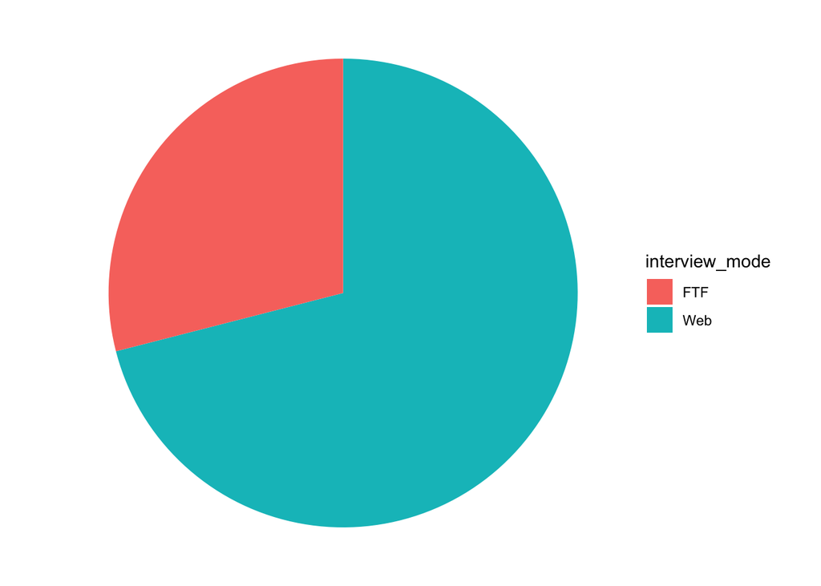

```
## # A tibble: 3 x 3
##   gender     n propotion
## * <chr>  <int>     <dbl>
## 1 female   526      0.15
## 2 male     484      0.14
## 3 <NA>    2507      0.71
```

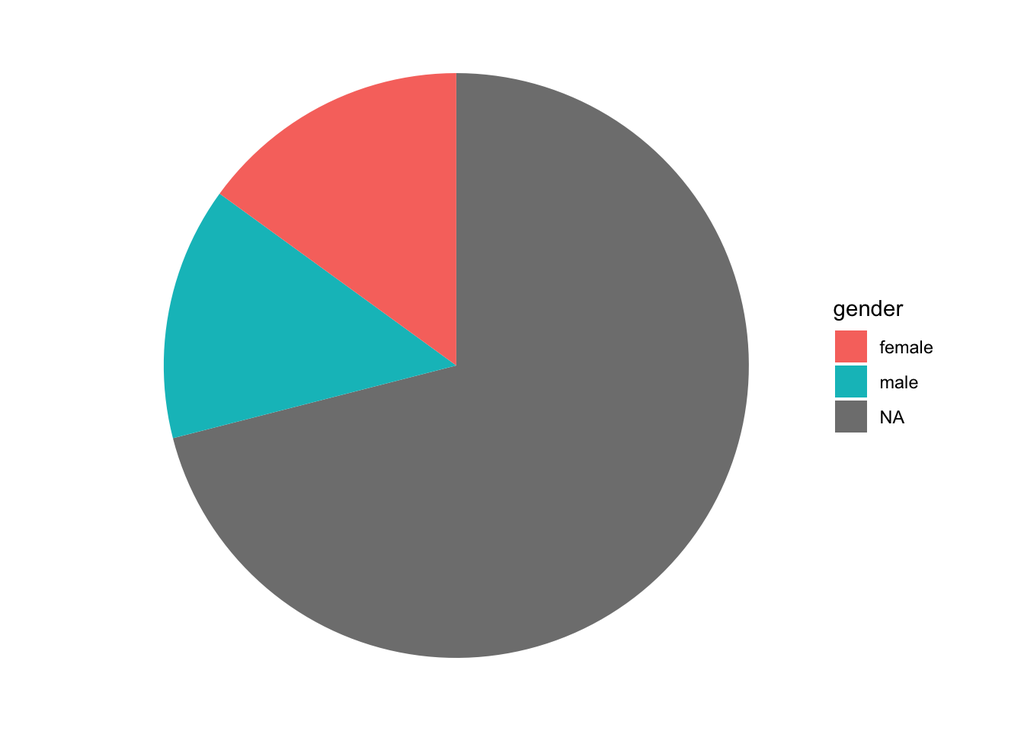

```
## # A tibble: 51 x 3
##    state     n propotion
##    <chr> <int>     <dbl>
##  1 CA      332      0.09
##  2 TX      270      0.08
##  3 IL      168      0.05
##  4 FL      165      0.05
##  5 PA      153      0.04
##  6 NY      147      0.04
##  7 NC      142      0.04
##  8 OH      135      0.04
##  9 TN      121      0.03
## 10 MI      116      0.03
## # … with 41 more rows
```

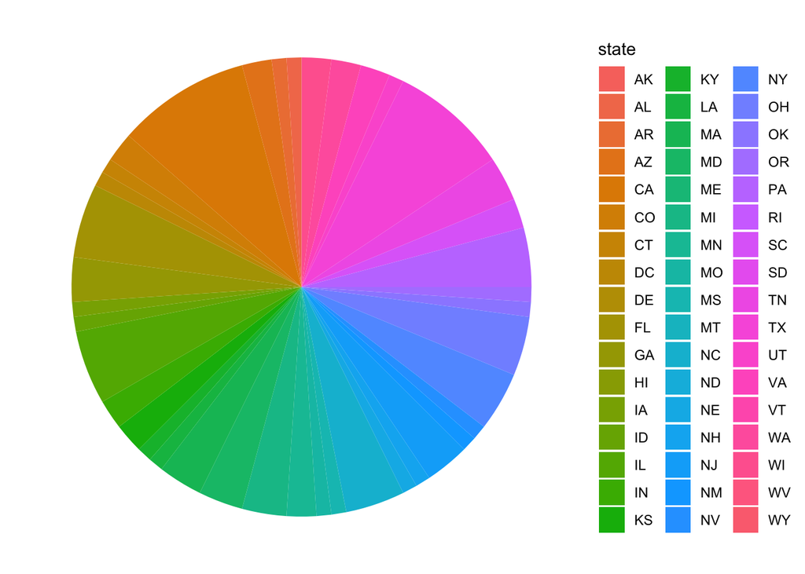

```
## # A tibble: 6 x 3
##   race                                 n propotion
##   <chr>                            <int>     <dbl>
## 1 white                             2542      0.72
## 2 Hispanic                           367      0.1
## 3 black                              332      0.09
## 4 other                              141      0.04
## 5 Asian                              112      0.03
## 6 Native American or Alaska Native    23      0.01
```

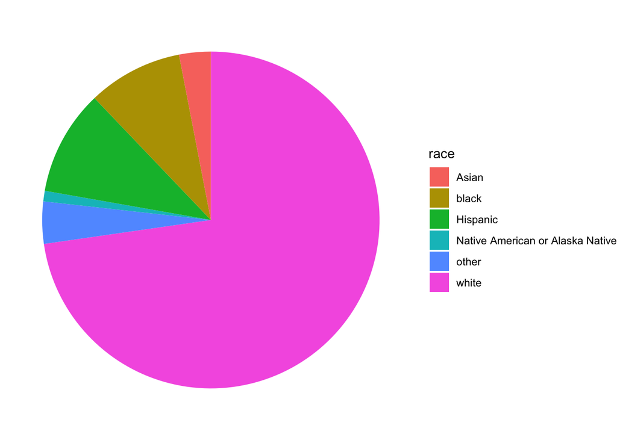

```
## # A tibble: 8 x 3
##   education                          n propotion
##   <chr>                          <int>     <dbl>
## 1 bachelor's degree                815      0.23
## 2 college but no degree            749      0.21
## 3 high school graduate             656      0.19
## 4 associate college degree         481      0.14
## 5 master's degree                  420      0.12
## 6 less than high school graduate   222      0.06
## 7 doctoral degree                  103      0.03
## 8 professional school degree        71      0.02
```

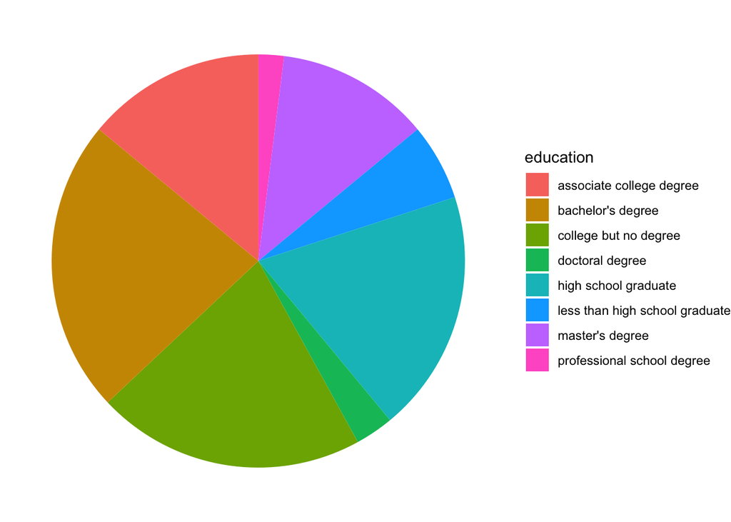

```
## # A tibble: 3 x 3
##   registration_turnout_status     n propotion
##   <chr>                       <int>     <dbl>
## 1 registered, voted            2736      0.78
## 2 registered, not voted         442      0.13
## 3 not registered, not voted     339      0.1
```

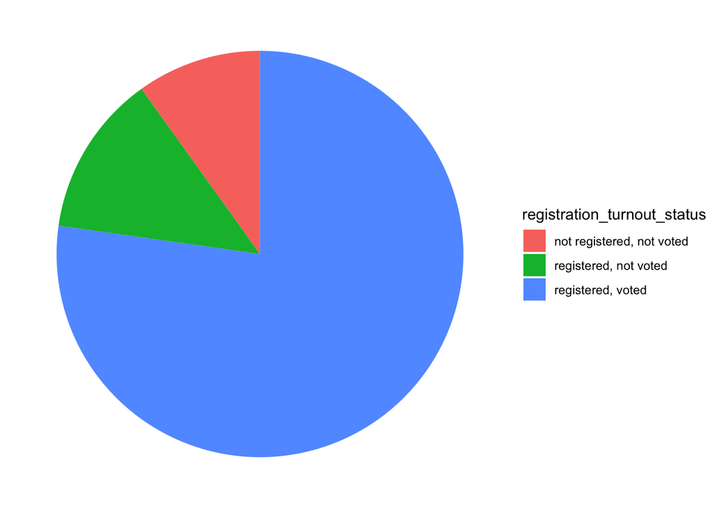

```
## # A tibble: 6 x 3
##   presidential_vote     n propotion
##   <chr>             <int>     <dbl>
## 1 Clinton            1296      0.37
## 2 Trump              1180      0.34
## 3 no vote             847      0.24
## 4 Johnson             116      0.03
## 5 others               47      0.01
## 6 Stein                31      0.01
```

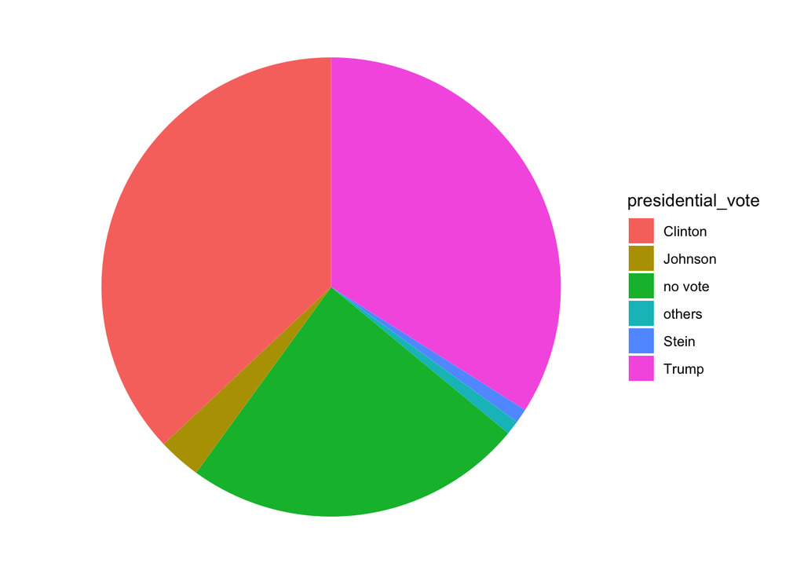

```
## # A tibble: 4 x 3
##   House_vote     n propotion
##   <chr>      <int>     <dbl>
## 1 no vote     1214      0.35
## 2 Republican  1137      0.32
## 3 Democratic  1101      0.31
## 4 others        65      0.02
```

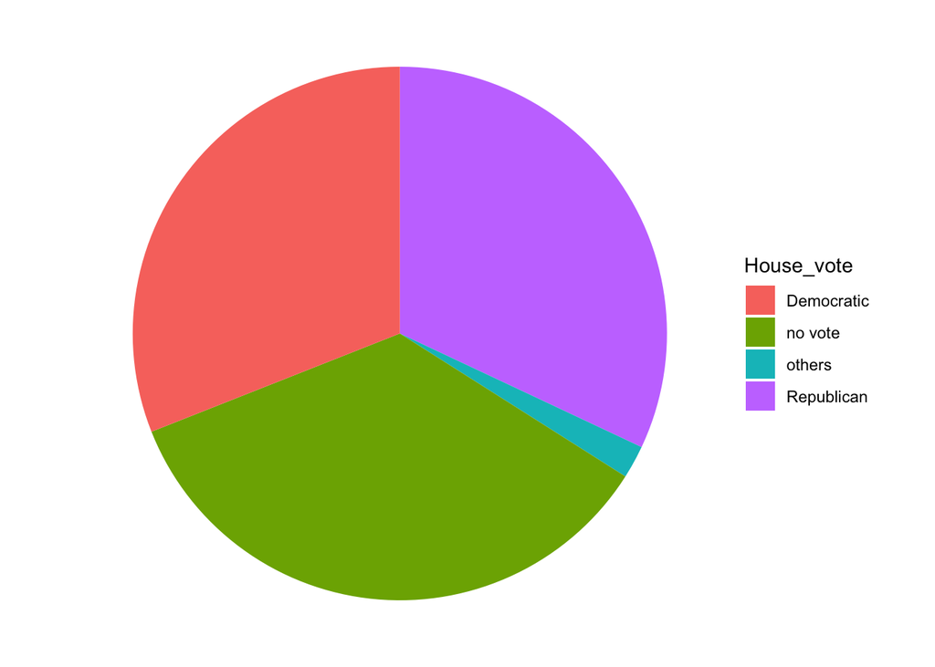

```
## # A tibble: 4 x 3
##   Governer_vote     n propotion
##   <chr>         <int>     <dbl>
## 1 no vote        3155      0.9
## 2 Democratic      215      0.06
## 3 Republican      146      0.04
## 4 others            1      0
```

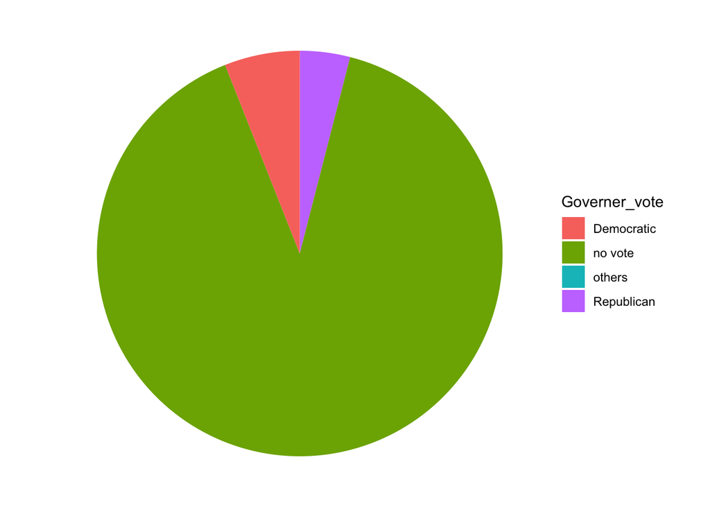

> From those pie plots and proportion tables for each variable, we can roughly check if they look invalid or strange, i.e. the equal proportion of the male and the female looks good, the major part in race of the observations, white, as expected, and so on. Therefore, it is valid and convincing to do futher investigation on the dataset after manipulations.

# Visualization

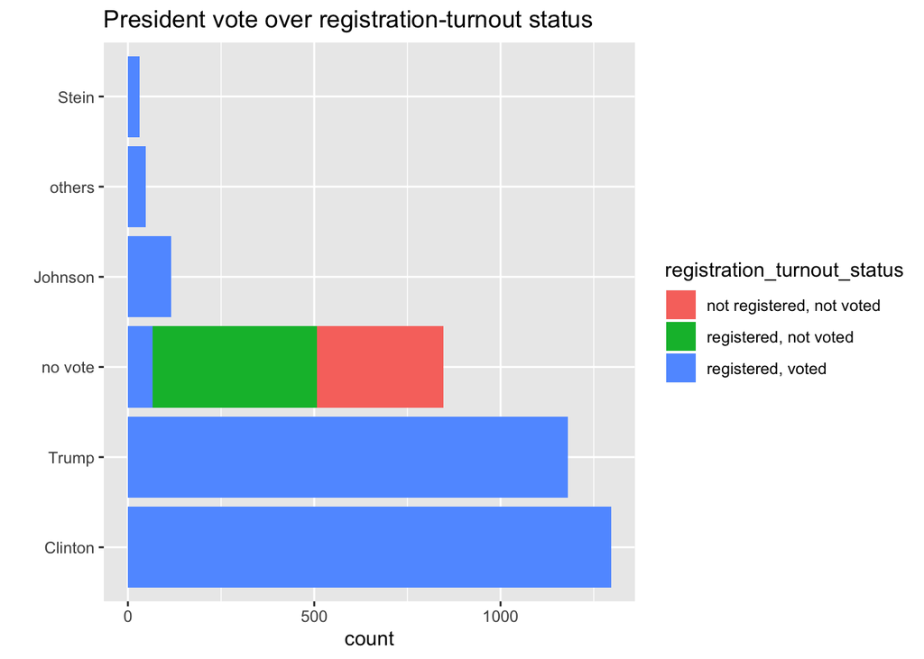

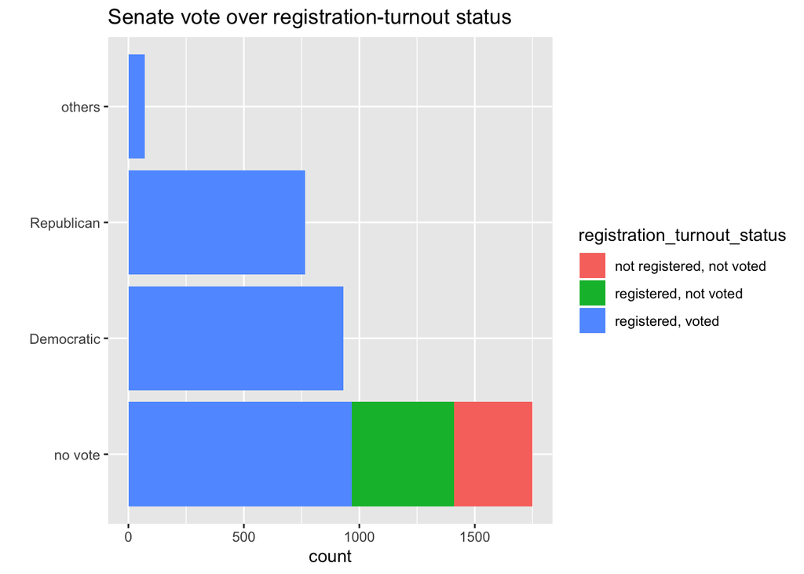

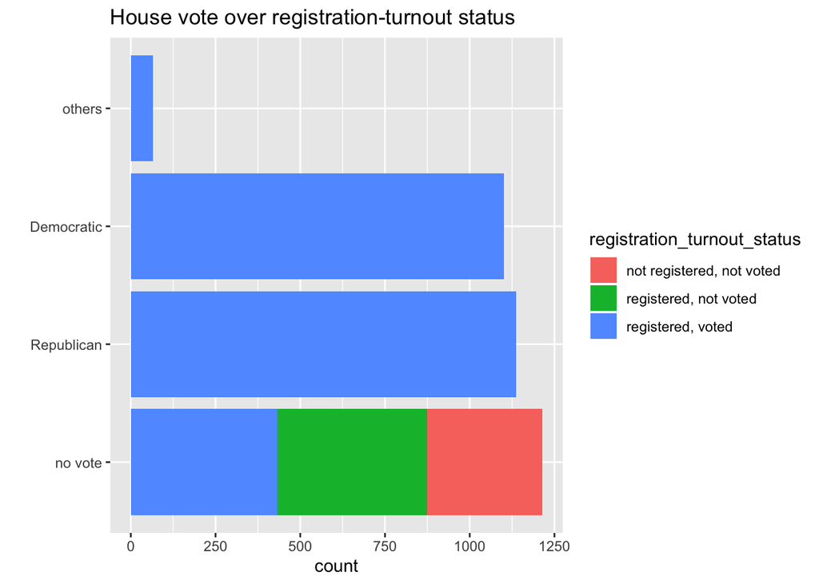

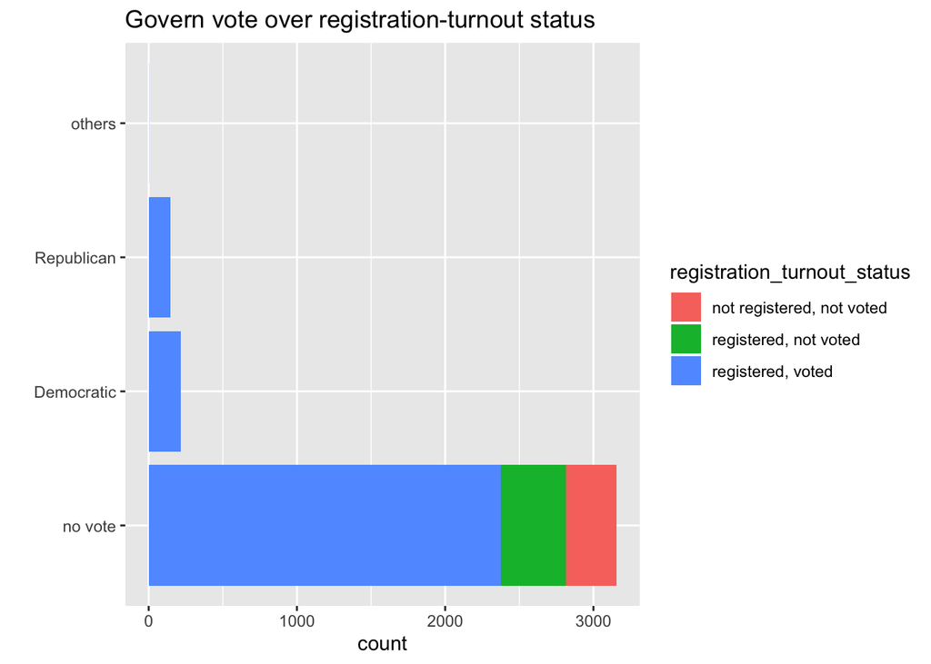

> The above 4 plots presents the distribution of votes for “president_vote”, “Senate_vote”, “House_vote” and “Governer_vote”. Clinton and Trump are the most popular candidates despite Clinton a little ahead. For Senate, House and Governer vite, Republican and eocratic have close votes. Democratic is a little ahead in Senate and Governer vote though Republican is a little ahead in House vote.

# Whethere the highest education degree you have would affact your registation-turnout status?

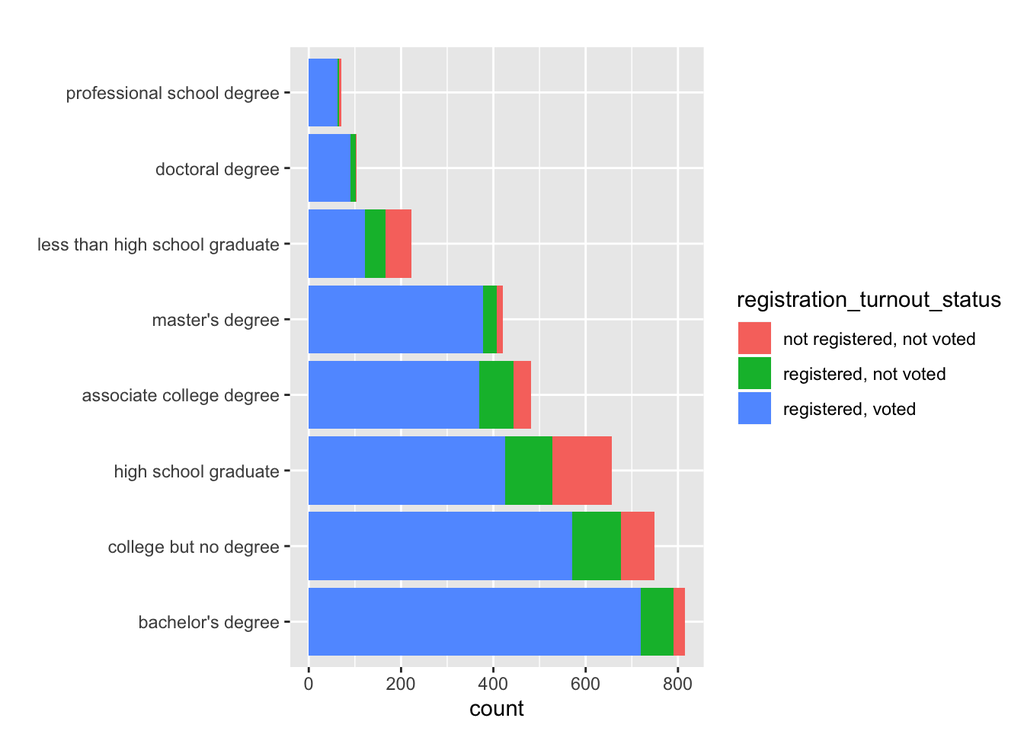

# Whether the race difference would affact your registration-turnout status?

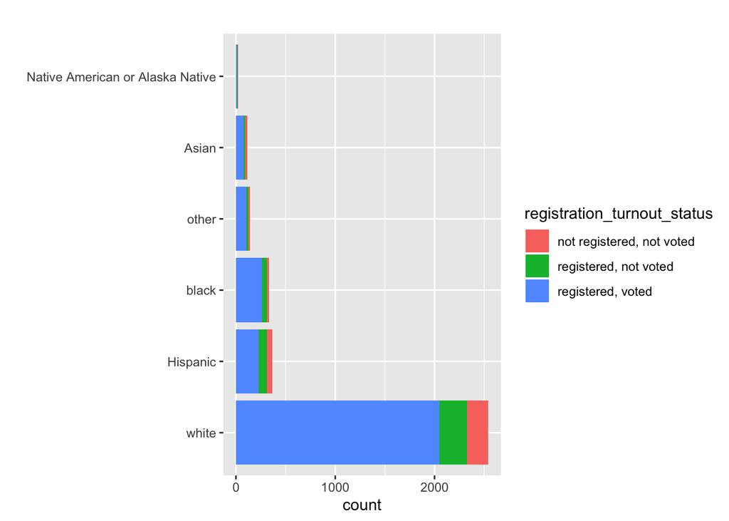